# Introduction to scRNA-seq - Part I: Quality Control

Maria Vlachonikolou

30/05/2023

#Introduction:

Single cell RNA-seq has revolutionized the field of cell biology as it allows for the study of each cell individually at the transcriptional level. This report aims to be an introduction to the workflow of single-cell RNA sequencing data analysis. The dataset used here contains cells from telencephali of adult *Pleurodeles waltl* salamander and is a subset of the dataset published in **Woych et al., 2022** (https://doi.org/10.1126/science.abp9186). The sequenced libraries were aligned to *P. waltl* reference transcriptome. Here, as well as in the original publication, the data are analysed using the Seurat R package.

The study investigates the evolution of advanced cognition in vertebrates in order to understand if certain characteristics of mammals and sauropsids are a result of convergent evolution or have a common origin. For this reason amphibians are used as an outgroup. The study based on the data builts a cell-atlas of the salamander telecephalon and identifies marker genes. Apart from being an outgroup for mammals and sauropsids, salamander gather special research interest as they have large genomes, extensive regeneration capabilities, long life span and complex social behavior. The telencephalon is a part of the vertabrate brain associated with higher functions such as memory, emotions and sensory information processing. As shown in this study, the salamander telencephalon is higly complex in terms of cell-type diversity.

The cells can be grouped into two main categories: neuronal and non-neuronal cells. Neurons are subsequently classified as excitatory or inhibitory, while non-neuronal cells are made up of distinct populations of glial cells.

The report is divided in five parts: Quality control, dimensionality reduction, clustering, annotations and further downstream analysis. Throughout this process the reconstructions of certain plots of the original publication based on the marker gene data they provide will be attempted.

# Kneepoint Plot

We use the knee point plot to find a cutoff for valid or “empty” droplets.

*Questions to be answered in the protocol:*

*What are valid and “empty” droplets?

In theory, a valid droplet in droplet based single-cell RNA sequencing contains only one cell along with a bead with primers for reverse transcription.

Empty droplets are those who have failed to capture a whole cell. Nevertheless, those droplets may still give some reads as they usually contain ambient RNA. These droplets have characteristically lower amount of reads compared to the valid ones and can be filtered out during the Quality Control step.

- Where do the reads come from that are in “empty” droplets?

Reads in “empty” droplets are a result of free floating transcripts, also known as *ambient RNA*. These transcripts may originate from ruptured, dead or dying cells whose cytoplasm is leaking out, naturally occurring extra-cellular RNA or from other exogenous sources of contamination.

- What are the x and y axes of the knee point plot?

To create the knee point plot, first the sum of all reads (UMIs) for each Cell Barcode is calculated. Then the Cell Barcodes are sorted by their total reads in decreasing order. Last, the sorted Cell Barcodes are plotted against the cumulative sum of their reads, meaning that the first point in the plot is the sum of reads of the first cell, the second is the cumulative sum of the reads of the first and second cell etc.

So, the y axis of the knee point plot represents the cumulative sum of reads. The numbers in the x-axis are simply the Cell Barcodes’ position in the sorted list.

- What does the cutoff point in the knee point plot represent?

In the knee point plot, initially, with every new cell’s reads added to the cumulative sum the curve grows exponentially. Every cell has less reads from the one before it and so the curve at some point visibly bends, from high slope to low slope, as the cell reads do not contribute significantly to the cumulative sum anymore. This is an indicator that from then on the droplets are “empty” and do not contain whole cells. To exclude the “empty” droplets from our analysis, we introduce a cutoff at this point.

## Loading the necessary packages

```r
library(Matrix)
library(KneeArrower)
library(Seurat)
```

## Loading the cell x gene matrix

```r
parent.dir <- "Pleurodeles_E5_2/"

mat <- readMM(paste0(parent.dir, "matrix.mtx"))
barcodes <- read.csv(paste0(parent.dir, "barcodes.tsv"), header = F)[[1]]
genes <- read.csv(paste0(parent.dir, "features.tsv"), header = F)[[1]]

colnames(mat) <- barcodes
rownames(mat) <- genes

dim(mat)
```

```
## [1] 16882 99634
```

Our matrix contains 16882 genes (Features) across 99634 droplets/ cells.

Inspection of the first five rows (Features) and columns (Cell Barcodes) of the matrix. The values in the matrix represent the number of UMIs corresponding to each feature that were detected in each cell. The . values represent 0s (no molecules detected).

```r
mat[1:5, 1:5]
```

```
## 5 x 5 sparse Matrix of class "dgTMatrix"
##          TGATCTTTCCGGCTTT GAAACCTTCCATTTGT AAACCCATCCTTCTTC TCAGTCCCACCTTCCA
## LGI3                    .                .                .                1
## ENTPD7                  .                1                1                1
## KIAA1644                1                1                2                .
## PI4KB                   2                2                .                3
## NUAK2                   1                .                .                .
##          TCCTAATCAGAAACCG
## LGI3                    .
## ENTPD7                  .
## KIAA1644               10
## PI4KB                   1
## NUAK2                   .
```

Our data is very sparse, the majority of values in our matrix are zeros. Bellow the fraction of non-zero values is calculated.

```r
sum(mat != 0) / length(mat)
```

```
## [1] 0.008170707
```

Only 0.8% of the data are non-zero! Sparse matrices are stored in a special format (sparse-matrix) to save memory and increase speed.

## Creating the knee point plot

First the number of reads (UMIs) are summed across cells (columns).

```r
umi.per.cell <- colSums(mat)
summary(umi.per.cell)
```

```
##    Min. 1st Qu.  Median    Mean 3rd Qu.    Max.
##     1.0    37.0    58.0   409.3    84.0 57172.0
```

The median value is 58, while the Mean is 409. This difference suggests that the distribution of the data is positively skewed, with a few very large values that significantly affect the mean. Indicating that a large proportion of droplets are “empty”.

Sorting Cells in decreasing order of reads.

```r
umi.per.cell <- sort(umi.per.cell, decreasing = T)
head(umi.per.cell)
```

```
## CTCAGAATCAACCCGG GTCCTCATCTTGAACG CCACCATAGGATAATC TCAGTGATCAGCTTCC
##            57172            55652            51664            50164
## GACCCAGGTCTACAAC GAACACTAGCCTGAGA
##            48882            48182
```

Calculation of the cumulative sums.

```r
cumulative.sum <- cumsum(umi.per.cell)
head(cumulative.sum)
```

```
## CTCAGAATCAACCCGG GTCCTCATCTTGAACG CCACCATAGGATAATC TCAGTGATCAGCTTCC
##            57172           112824           164488           214652
## GACCCAGGTCTACAAC GAACACTAGCCTGAGA
##           263534           311716
```

Knee point plot

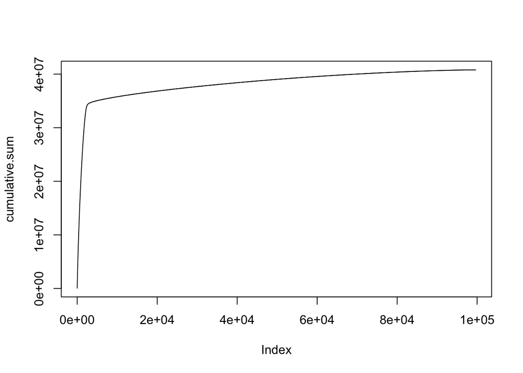

```r
plot(cumulative.sum, type = "l")
```

Zoom in to the Knee Point.

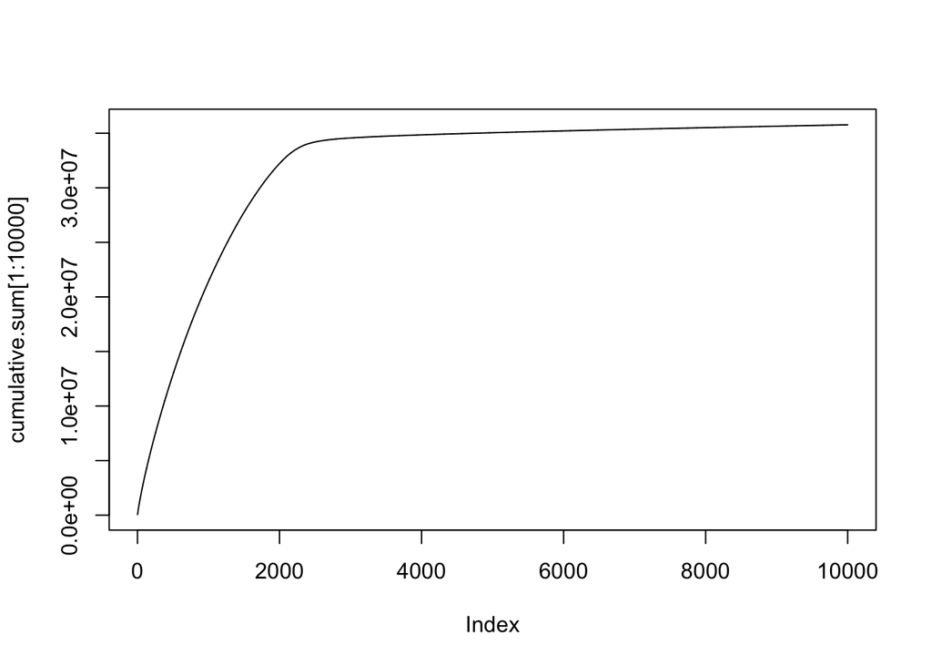

```r
plot(cumulative.sum[1:10000], type = "l")
```

## Finding the knee point

The findCutoff() function is used to calculate the cutoff point. The method as used here finds the first point where the slope of the function drops to 1/10 of that of the steepest slope on the curve.

```r
knee <- findCutoff(
  2000:5000,
  cumulative.sum[2000:5000],
  method = "first",
  frac.of.steepest.slope = 0.1
)
ceiling(knee$x)
```

```
## [1] 2722
```

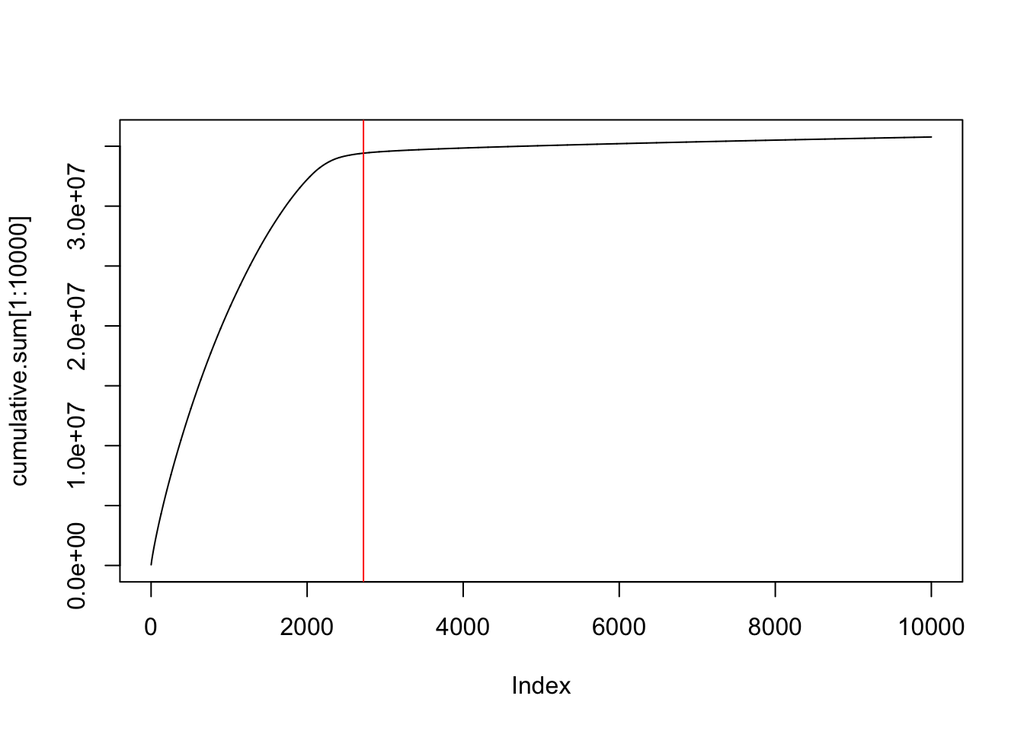

```r
plot(cumulative.sum[1:10000], type = "l")
abline(v = ceiling(knee$x), col = "red")
```

The cutoff is at the 2722th out of the 99634 total cells. Meaning that 97% of the Cell Barcodes are considered “empty” for the purposes of this study and are excluded from the analysis.

```r
umi.per.cell[2722]
```

```
## TCTAACTAGGTCGCCT
##              701
```

The 2722th cell has 701 UMIs.

## Creating a subset of the matrix

Creation of a new matrix including only the top 2722 cells with the highest amount of reads and storage of the data in a new folder.

```r
sub.mat <- mat[, names(cumulative.sum[1:ceiling(knee$x)])]
dim(sub.mat)
```

```
## [1] 16882  2722
```

```r
out.name <- "Pleurodeles_E5_2_filtered"
if (!dir.exists(out.name)) {
  dir.create(out.name)
}
writeMM(sub.mat, paste0(out.name, "/matrix.mtx"))
```

```r
write(colnames(sub.mat), paste0(out.name, "/barcodes.tsv"))
write(rownames(sub.mat), paste0(out.name, "/features.tsv"))
```

# The Seurat Object

The Seurat package contains many functions for analyzing scRNA-seq data in R. We create a Seurat object from our subset. Here we already filter out some cells and genes based on the parameters set in `min.cells` and `min.features`.

*Questions to be answered in the protocol:*

- What do the arguments `min.cells` and `min.features` in the `CreateSeuratObject()` function do?

Our data as it is now still need further filtering to exclude features (genes) that are expressed in only in very few cells and cells that contain very few features. The minimum amount of cells a feature has to be detected in, `min.cells`, is set to 3. This removes features that are unlikely to play any part in differentiating groups of cells due to being expressed in very few cells. The minimum amount of features that have to be detected in a cell, `min.features`, is set to 200, excluding dead cells, empty droplets and outliers in general. First the cell filtering takes place, followed by the gene filtering.

```r
ple5 <- CreateSeuratObject(
  counts = sub.mat,
  project = "Pleurodeles",
  min.cells = 3,
  min.features = 200
)
```

Only features and cells that meet the set criteria are included in the Seurat Object.

```r
ple5
```

```
## An object of class Seurat
## 13103 features across 2688 samples within 1 assay
## Active assay: RNA (13103 features, 0 variable features)
```

## More QC metrics

In the next steps we will look at three additional metrics for finding high-quality cells and then subset our Seurat object using suitable cutoff values for each metric.

*Questions to be answered in the protocol:*

- What do the metrics `nFeature_RNA` and `nCount_RNA` and `percent_mito` represent?

A few QC metrics commonly used by the community include the number of unique genes detected in each cell (`nFeature_RNA`), the total number of molecules detected within a cell (`nCount_RNA`) and the percentage of all the counts belonging to a subset of features that are encoded in the mitochondrial genome (`percent_mito`).

To set the thresholds for those parameters, it is useful to plot them first and see where the outliers lie. Damaged cells or empty droplets will often have very few features and counts. On the other hand, droplets containing more than one cell may exhibit a very high number of UMIs (counts).

Low-quality/ dying cells can occur in any sample and may be a cause of clustering artifacts. For this purpose the percentage of mitochondrial gene reads is used. It has been shown that high proportions are indicative of poor-quality cells, as for example it is less likely for mRNA in the mitochondria to escape from a perforated cell, compared to cytosolic transcripts that easily leak out in that case.

```r
mitochondrial_genes_salamander <- c(
  "ND1", "ND4L","ND5","ND6","COX1","COX2","COX3","CYTB","ATP6"
  )

ple5[["percent_mito"]] <- PercentageFeatureSet(
  ple5,
  features = mitochondrial_genes_salamander
)
```

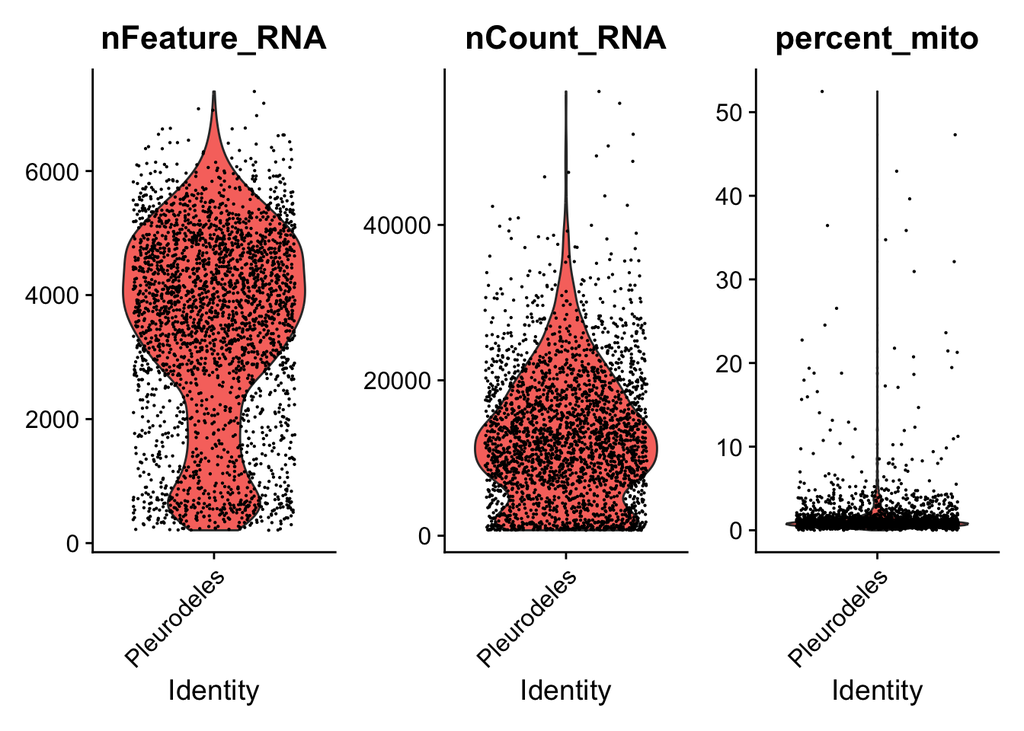

```r
#Visualization of QC metrics
VlnPlot(ple5, features = c(
  "nFeature_RNA", "nCount_RNA", "percent_mito"
), ncol = 3, pt.size = 0.1)
```

Each dot in the above plots represents an individual cell. On the y-axis the values for each metric are shown.

```r
summary(ple5$nFeature_RNA)
```

```
##    Min. 1st Qu.  Median    Mean 3rd Qu.    Max.
##     207    2649    3796    3513    4700    7283
```

```r
summary(ple5$nCount_RNA)
```

```
##    Min. 1st Qu.  Median    Mean 3rd Qu.    Max.
##     701    6830   11986   12788   17809   57172
```

```r
summary(ple5$percent_mito)
```

```
##    Min. 1st Qu.  Median    Mean 3rd Qu.    Max.
##  0.0000  0.5974  0.8913  1.5035  1.3164 52.4715
```

For the number of Features some outliers towards lower values are detected. The number of Ρeads exhibits outliers at both directions. In the case of the mitochondrial reads percentage some data points are skewed towards high values, although 3/4 of them are bellow 1.32%.

The next step is to subset the Seurat Object according to the above analysis and exclude the highly deviant data points.

```r
ple5 <- subset(ple5,
               subset = nFeature_RNA > 500 &
                 nCount_RNA > 500 &
                 nCount_RNA < 30000 &
                 percent_mito < 3)
```

Distribution of cells after filtering:

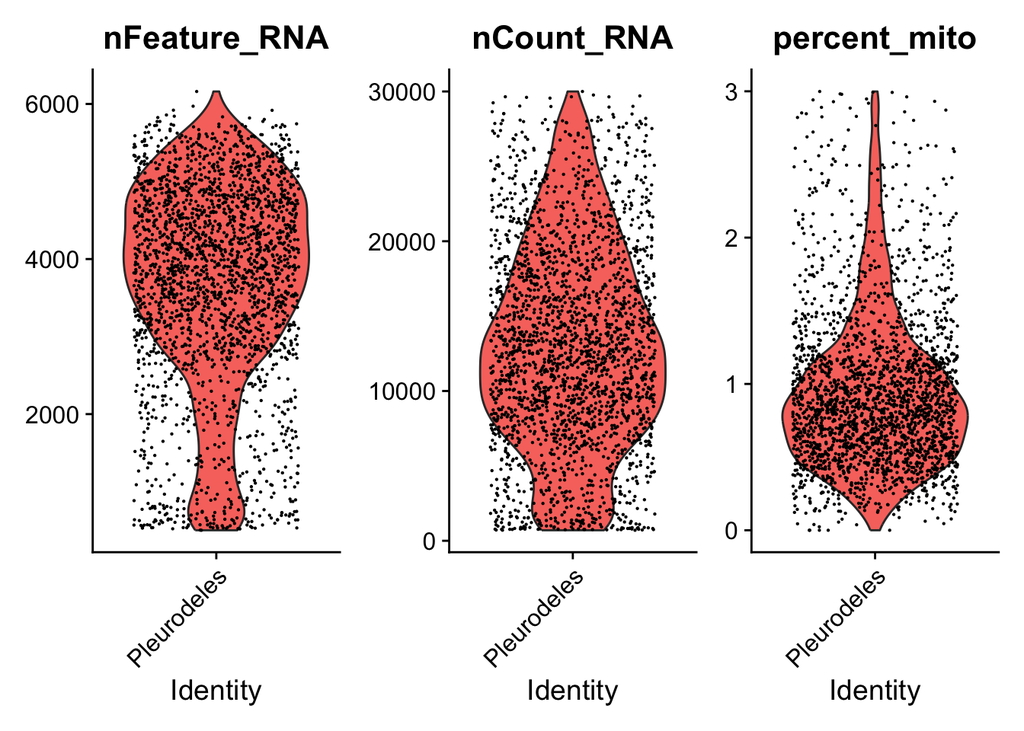

```r
VlnPlot(ple5, features = c(
  "nFeature_RNA", "nCount_RNA", "percent_mito"
), ncol = 3, pt.size = 0.1)
```

# Saving the Seurat object for later use

```r
saveRDS(ple5, "srt_01_ple5v2.rds")
```